Sita Dawanse:

[GitHub_link](https://sdawanse.github.io)

# Trends in Renewable Energy Adoption

This dataset was obtained from the Kaggle dataset webpage [Global Data on Sustainable Energy](https://www.kaggle.com/datasets/anshtanwar/global-data-on-sustainable-energy) This dataset contains sustainable energy indicators and other useful factors across all countries from 2000 to 2020, including vital aspects like electricity access, renewable energy, carbon emissions, energy intensity, Financial flows, and economic growth. With the help of this data we expect to gain profound insights into global energy consumption patterns over time.Therefore the goal fo this project is to investigate the pattern of energy consumption and their consequences on climate by the emission greenhouse gas, global temperture rise.

We would like to examine electricity produced from different resources by different countries and how the production and consumption has changed over time, access of electricity to the percentage of population over time. This data provides a score for each country individually every year, we can use this data to compare the trends from different countries and dive deeper into how the production, consumption and accessibility are affected by financial flows, and economic growth. We can also answer questions such as, what issues are most prevalent in the world for the clean and renewal energy? Furthermore, we can examine the data alongside other country-wide factor datasets such as gdp_growth, gdp_per_capita, Land Area, Latitude, Longitude.

The Questions that I'm addressing here is

1. What is the relative contribution of fossil fuels, nuclear, and renewables to a country's total electricity generation, and how has this mix changed over time?
2. What is the relationship between a country's renewable energy capacity and its share of renewable energy consumption, and how does this relate to CO2 emissions?

```python
# Import the important Libraries

import pandas as pd
import numpy as np
import re
import matplotlib.pyplot as plt
import seaborn as sns

pd.set_option("display.max_rows", None, "display.max_columns", None)

from google.colab import drive
drive.mount('/content/drive')
```

## ETL (Extraction, Transform, and Load)

We load the dataset Global Data on Sustainable Energy to Pandas DataFrame. This dataset shows the year, country, each country’s access to electricity, access clean cooking fuel, financial flow, electricity from different fuels and all others variables. We will tidy the data by taking the the specific columns required for the analysis and visualization.

```python
# Loading the dataset to Pandas DataFrame
Energy_df = pd.read_csv("/content/drive/MyDrive/Data_Science/project/Global/global-data-on-sustainable-energy.csv")
Energy_df.head()
Energy_df.tail()
```

|  | Entity | Year | Access to electricity (% of population) | Access to clean fuels for cooking | Renewable-electricity-generating-capacity-per-capita | Financial flows to developing countries (US $) | Renewable energy share in the total final energy consumption (%) | Electricity from fossil fuels (TWh) | Electricity from nuclear (TWh) | Electricity from renewables (TWh) | Low-carbon electricity (% electricity) | Primary energy consumption per capita (kWh/person) | Energy intensity level of primary energy (MJ/$2017 PPP GDP) | Value_co2_emissions_kt_by_country | Renewables (% equivalent primary energy) | gdp_growth | gdp_per_capita | Density\n(P/Km2) | Land Area(Km2) | Latitude | Longitude |
| --- | --- | --- | --- | --- | --- | --- | --- | --- | --- | --- | --- | --- | --- | --- | --- | --- | --- | --- | --- | --- | --- |
| 3644 | Zimbabwe | 2016 | 42.561730 | 29.8 | 62.88 | 30000.0 | 81.90 | 3.50 | 0.0 | 3.32 | 48.680350 | 3227.6802 | 10.00 | 11020.00046 | NaN | 0.755869 | 1464.588957 | 38 | 390757.0 | -19.015438 | 29.154857 |
| 3645 | Zimbabwe | 2017 | 44.178635 | 29.8 | 62.33 | 5570000.0 | 82.46 | 3.05 | 0.0 | 4.30 | 58.503407 | 3068.0115 | 9.51 | 10340.00015 | NaN | 4.709492 | 1235.189032 | 38 | 390757.0 | -19.015438 | 29.154857 |
| 3646 | Zimbabwe | 2018 | 45.572647 | 29.9 | 82.53 | 10000.0 | 80.23 | 3.73 | 0.0 | 5.46 | 59.412407 | 3441.9858 | 9.83 | 12380.00011 | NaN | 4.824211 | 1254.642265 | 38 | 390757.0 | -19.015438 | 29.154857 |
| 3647 | Zimbabwe | 2019 | 46.781475 | 30.1 | 81.40 | 250000.0 | 81.50 | 3.66 | 0.0 | 4.58 | 55.582527 | 3003.6553 | 10.47 | 11760.00023 | NaN | -6.144236 | 1316.740657 | 38 | 390757.0 | -19.015438 | 29.154857 |
| 3648 | Zimbabwe | 2020 | 52.747670 | 30.4 | 80.61 | 30000.0 | 81.90 | 3.40 | 0.0 | 4.19 | 55.204216 | 2680.1318 | 10.00 | NaN | NaN | -6.248748 | 1214.509820 | 38 | 390757.0 | -19.015438 | 29.154857 |

Retrieving the data corresponding to countries located in North America

```python
#Listing the North_American countries
north_america_countries = ['Antigua and Barbuda','Bahamas','Barbados','Belize','Canada','Costa Rica','Cuba', 'Dominica',
    'Dominican Republic','El Salvador','Grenada','Guatemala','Haiti','Honduras','Jamaica','Mexico','Nicaragua',
    'Panama','Saint Kitts and Nevis','Saint Lucia','Saint Vincent and the Grenadines','Trinidad and Tobago',
    'United States']

# Filtering the DataFrame to include only North_american countries
north_america_df = Energy_df.loc[Energy_df['Entity'].isin(north_america_countries)].copy()

# Save north_america_df to csv file
north_america_df.to_csv("north_america_data.csv", index = False)

North_america_df = pd.read_csv("/content/north_america_data.csv")
North_america_df.head()
```

|  | Entity | Year | Access to electricity (% of population) | Access to clean fuels for cooking | Renewable-electricity-generating-capacity-per-capita | Financial flows to developing countries (US $) | Renewable energy share in the total final energy consumption (%) | Electricity from fossil fuels (TWh) | Electricity from nuclear (TWh) | Electricity from renewables (TWh) | Low-carbon electricity (% electricity) | Primary energy consumption per capita (kWh/person) | Energy intensity level of primary energy (MJ/$2017 PPP GDP) | Value_co2_emissions_kt_by_country | Renewables (% equivalent primary energy) | gdp_growth | gdp_per_capita | Density\n(P/Km2) | Land Area(Km2) | Latitude | Longitude |
| --- | --- | --- | --- | --- | --- | --- | --- | --- | --- | --- | --- | --- | --- | --- | --- | --- | --- | --- | --- | --- | --- |
| 0 | Antigua and Barbuda | 2000 | 97.689260 | 100.0 | 0.0 | NaN | 0.0 | 0.14 | 0.0 | 0.0 | 0.0 | 28457.223 | 3.13 | 330.000000 | NaN | 6.203431 | 10872.29295 | 223 | 443.0 | 17.060816 | -61.796428 |
| 1 | Antigua and Barbuda | 2001 | 97.785255 | 100.0 | 0.0 | NaN | 0.0 | 0.16 | 0.0 | 0.0 | 0.0 | 28025.290 | 3.31 | 350.000000 | NaN | -4.548003 | 10367.31961 | 223 | 443.0 | 17.060816 | -61.796428 |
| 2 | Antigua and Barbuda | 2002 | 100.000000 | 100.0 | 0.0 | NaN | 0.0 | 0.18 | 0.0 | 0.0 | 0.0 | 29660.344 | 3.59 | 389.999986 | NaN | 1.027442 | 10401.05088 | 223 | 443.0 | 17.060816 | -61.796428 |
| 3 | Antigua and Barbuda | 2003 | 97.956825 | 100.0 | 0.0 | NaN | 0.0 | 0.20 | 0.0 | 0.0 | 0.0 | 30824.252 | 3.63 | 409.999996 | NaN | 6.076544 | 10797.95106 | 223 | 443.0 | 17.060816 | -61.796428 |
| 4 | Antigua and Barbuda | 2004 | 98.037100 | 100.0 | 0.0 | NaN | 0.0 | 0.21 | 0.0 | 0.0 | 0.0 | 31622.059 | 3.57 | 400.000006 | NaN | 5.767029 | 11446.96914 | 223 | 443.0 | 17.060816 | -61.796428 |

```python
display(North_america_df.dtypes)
```

```
Entity                                                               object
Year                                                                  int64
Access to electricity (% of population)                             float64
Access to clean fuels for cooking                                   float64
Renewable-electricity-generating-capacity-per-capita                float64
Financial flows to developing countries (US $)                      float64
Renewable energy share in the total final energy consumption (%)    float64
Electricity from fossil fuels (TWh)                                 float64
Electricity from nuclear (TWh)                                      float64
Electricity from renewables (TWh)                                   float64
Low-carbon electricity (% electricity)                              float64
Primary energy consumption per capita (kWh/person)                  float64
Energy intensity level of primary energy (MJ/$2017 PPP GDP)         float64
Value_co2_emissions_kt_by_country                                   float64
Renewables (% equivalent primary energy)                            float64
gdp_growth                                                          float64
gdp_per_capita                                                      float64
Density\n(P/Km2)                                                      int64
Land Area(Km2)                                                      float64
Latitude                                                            float64
Longitude                                                           float64
dtype: object
```

```python
# Set 'Entity' and 'Year' columns as index
North_america_df.set_index(['Entity', 'Year'], inplace=True)
North_america_df.head()
```

| Entity | Year | Access to electricity (% of population) | Access to clean fuels for cooking | Renewable-electricity-generating-capacity-per-capita | Financial flows to developing countries (US $) | Renewable energy share in the total final energy consumption (%) | Electricity from fossil fuels (TWh) | Electricity from nuclear (TWh) | Electricity from renewables (TWh) | Low-carbon electricity (% electricity) | Primary energy consumption per capita (kWh/person) | Energy intensity level of primary energy (MJ/$2017 PPP GDP) | Value_co2_emissions_kt_by_country | Renewables (% equivalent primary energy) | gdp_growth | gdp_per_capita | Density\n(P/Km2) | Land Area(Km2) | Latitude | Longitude |
| --- | --- | --- | --- | --- | --- | --- | --- | --- | --- | --- | --- | --- | --- | --- | --- | --- | --- | --- | --- | --- |
| Antigua and Barbuda | 2000 | 97.689260 | 100.0 | 0.0 | NaN | 0.0 | 0.14 | 0.0 | 0.0 | 0.0 | 28457.223 | 3.13 | 330.000000 | NaN | 6.203431 | 10872.29295 | 223 | 443.0 | 17.060816 | -61.796428 |
|  | 2001 | 97.785255 | 100.0 | 0.0 | NaN | 0.0 | 0.16 | 0.0 | 0.0 | 0.0 | 28025.290 | 3.31 | 350.000000 | NaN | -4.548003 | 10367.31961 | 223 | 443.0 | 17.060816 | -61.796428 |
|  | 2002 | 100.000000 | 100.0 | 0.0 | NaN | 0.0 | 0.18 | 0.0 | 0.0 | 0.0 | 29660.344 | 3.59 | 389.999986 | NaN | 1.027442 | 10401.05088 | 223 | 443.0 | 17.060816 | -61.796428 |
|  | 2003 | 97.956825 | 100.0 | 0.0 | NaN | 0.0 | 0.20 | 0.0 | 0.0 | 0.0 | 30824.252 | 3.63 | 409.999996 | NaN | 6.076544 | 10797.95106 | 223 | 443.0 | 17.060816 | -61.796428 |
|  | 2004 | 98.037100 | 100.0 | 0.0 | NaN | 0.0 | 0.21 | 0.0 | 0.0 | 0.0 | 31622.059 | 3.57 | 400.000006 | NaN | 5.767029 | 11446.96914 | 223 | 443.0 | 17.060816 | -61.796428 |

```python
# Fill NaN in each column by 0
North_america_df.fillna(0, inplace = True);
```

```python
# Check missing values in columns
North_america_df.isnull().sum(axis=0)
```

```
Access to electricity (% of population)                             0
Access to clean fuels for cooking                                   0
Renewable-electricity-generating-capacity-per-capita                0
Financial flows to developing countries (US $)                      0
Renewable energy share in the total final energy consumption (%)    0
Electricity from fossil fuels (TWh)                                 0
Electricity from nuclear (TWh)                                      0
Electricity from renewables (TWh)                                   0
Low-carbon electricity (% electricity)                              0
Primary energy consumption per capita (kWh/person)                  0
Energy intensity level of primary energy (MJ/$2017 PPP GDP)         0
Value_co2_emissions_kt_by_country                                   0
Renewables (% equivalent primary energy)                            0
gdp_growth                                                          0
gdp_per_capita                                                      0
Density\n(P/Km2)                                                    0
Land Area(Km2)                                                      0
Latitude                                                            0
Longitude                                                           0
dtype: int64
```

```python
# Checking missing values in rows
North_america_df.isnull().sum(axis=1);
```

```python
# check the statistical information for the dataset
North_america_df.describe()
```

|  | Access to electricity (% of population) | Access to clean fuels for cooking | Renewable-electricity-generating-capacity-per-capita | Financial flows to developing countries (US $) | Renewable energy share in the total final energy consumption (%) | Electricity from fossil fuels (TWh) | Electricity from nuclear (TWh) | Electricity from renewables (TWh) | Low-carbon electricity (% electricity) | Primary energy consumption per capita (kWh/person) | Energy intensity level of primary energy (MJ/$2017 PPP GDP) | Value_co2_emissions_kt_by_country | Renewables (% equivalent primary energy) | gdp_growth | gdp_per_capita | Density\n(P/Km2) | Land Area(Km2) | Latitude | Longitude |
| --- | --- | --- | --- | --- | --- | --- | --- | --- | --- | --- | --- | --- | --- | --- | --- | --- | --- | --- | --- |
| count | 483.000000 | 483.000000 | 483.000000 | 4.830000e+02 | 483.000000 | 483.000000 | 483.000000 | 483.000000 | 483.000000 | 483.000000 | 483.000000 | 4.830000e+02 | 483.000000 | 483.000000 | 483.000000 | 483.000000 | 4.830000e+02 | 483.000000 | 483.000000 |
| mean | 91.237958 | 81.656004 | 86.770683 | 1.903126e+07 | 21.572712 | 136.656812 | 38.618137 | 41.593934 | 29.428154 | 26587.691064 | 4.304741 | 2.671328e+05 | 1.781932 | 1.900436 | 8961.279285 | 188.913043 | 9.793458e+05 | 18.481245 | -77.149814 |
| std | 13.664655 | 24.773086 | 121.423265 | 6.717739e+07 | 21.447954 | 559.528519 | 161.532173 | 128.185234 | 29.014980 | 35566.004222 | 3.732953 | 1.064432e+06 | 6.002859 | 4.070652 | 12683.050130 | 154.419152 | 2.786825e+06 | 9.975725 | 14.103692 |
| min | 31.542381 | 2.600000 | 0.000000 | 0.000000e+00 | 0.000000 | 0.030000 | 0.000000 | 0.000000 | 0.000000 | 836.080400 | 0.000000 | 0.000000e+00 | 0.000000 | -20.192371 | 0.000000 | 4.000000 | 2.610000e+02 | 8.537981 | -106.346771 |
| 25% | 88.013810 | 82.450000 | 2.375000 | 0.000000e+00 | 5.360000 | 0.265000 | 0.000000 | 0.010000 | 0.490316 | 8666.838500 | 2.560000 | 1.950000e+02 | 0.000000 | 0.000000 | 1489.301724 | 58.000000 | 6.160000e+02 | 12.984305 | -88.497650 |
| 50% | 96.802520 | 89.600000 | 52.620000 | 0.000000e+00 | 12.560000 | 1.890000 | 0.000000 | 0.450000 | 20.952381 | 11274.687000 | 3.540000 | 5.240000e+03 | 0.000000 | 2.202086 | 4718.436581 | 167.000000 | 2.296600e+04 | 15.783471 | -77.781167 |
| 75% | 100.000000 | 100.000000 | 110.170000 | 1.415000e+06 | 32.775000 | 6.515000 | 0.000000 | 4.120000 | 52.462604 | 26481.503500 | 4.900000 | 1.577500e+04 | 0.000000 | 4.109209 | 10330.594430 | 284.000000 | 1.108600e+05 | 18.971187 | -61.679000 |
| max | 100.000000 | 100.000000 | 622.840000 | 5.963700e+08 | 82.190000 | 2988.240000 | 809.410000 | 821.400000 | 99.121710 | 165831.280000 | 21.600000 | 5.775810e+06 | 30.542150 | 14.440990 | 65279.529030 | 668.000000 | 9.984670e+06 | 56.130366 | -59.543198 |

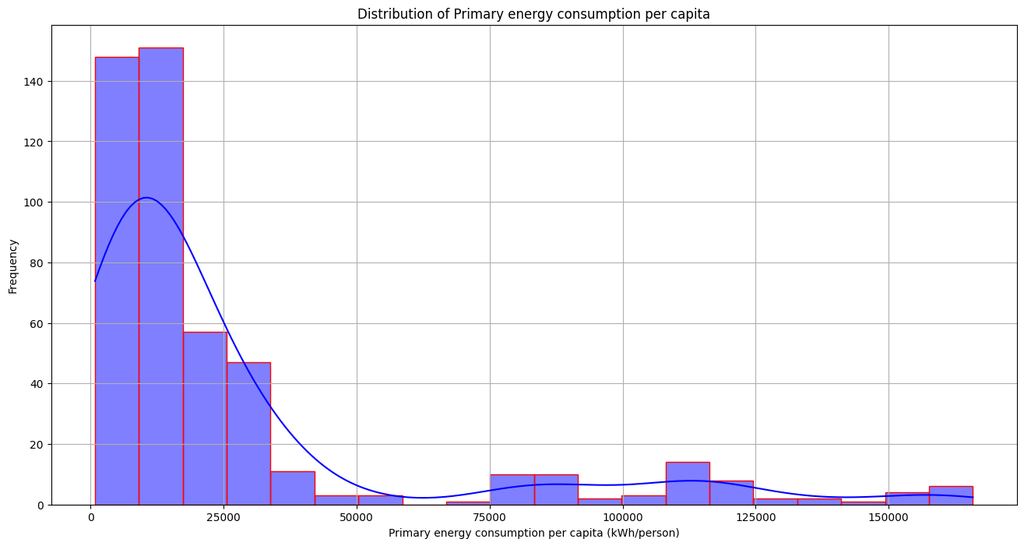

```python
#Plot the histogram and distribution plot together
plt.figure(figsize=(16, 8))
sns.histplot(North_america_df['Primary energy consumption per capita (kWh/person)'],
             bins=20,  kde=True, color='blue', edgecolor='red')
plt.xlabel('Primary energy consumption per capita (kWh/person)')
plt.ylabel('Frequency')
plt.title('Distribution of Primary energy consumption per capita')
plt.grid(True)
plt.show()
```

The above plot shows a strongly skewed distribution to the right, with the majority of countries having relatively low primary energy consumption per capita, as represented by the tall bars on the left side of the plot. The top bar reflects a significant number of countries, with primary energy consumption per capita ranging from 0 to 25,000 kWh.As energy consumption per capita grows, the height of the bars decreases, showing that fewer countries are in the higher consumption range.There is a large tail on the right side of the plot, indicating that a small number of countries have extremely high primary energy consumption per capita, ranging from approximately 75,000 kWh/person to 150,000 kWh.

A bar plot with distribution is a suitable visualization choice for displaying the primary energy consumption per capita data as it shows the frequency or count of observations (countries/regions) for different ranges of primary energy consumption per capita values. This allows us to see the overall distribution shape and identify any clusters or outliers in the data.

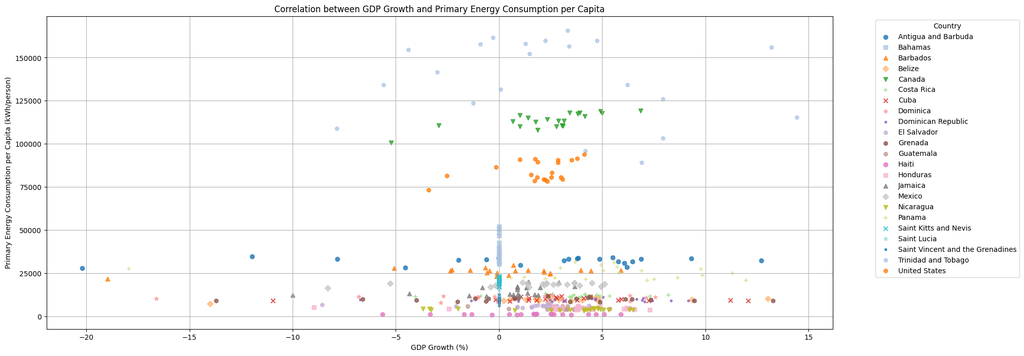

```python
# Extract the columns for GDP growth, primary energy consumption per capita, and country
gdp_growth = North_america_df['gdp_growth']
energy_consumption_per_capita = North_america_df['Primary energy consumption per capita (kWh/person)']
countries = North_america_df.index.get_level_values('Entity')

# Create a dictionary to map countries to unique markers and colors
country_marker_map = {}
country_color_map = {}
unique_countries = countries.unique()
markers = ['o', 's', '^', 'D', 'v', '+', 'x', '*', '.', 'p', 'h', 'H']        # Different marker styles
colors = plt.cm.tab20.colors            # Using the tab20 colormap for a variety of distinct colors
for i, country in enumerate(unique_countries):
    country_marker_map[country] = markers[i % len(markers)]   # Cycle through markers if more countries than markers
    country_color_map[country] = colors[i % len(colors)]      # Cycle through colors if more countries than colors

# Create the scatter plot, using different markers and colors for each country
plt.figure(figsize=(20, 8))
for country in unique_countries:
    country_data = North_america_df.loc[country]
    plt.scatter(country_data['gdp_growth'], country_data['Primary energy consumption per capita (kWh/person)'],
                marker=country_marker_map[country], color=country_color_map[country], alpha=0.8, label=country)
plt.title('Correlation between GDP Growth and Primary Energy Consumption per Capita')
plt.xlabel('GDP Growth (%)')
plt.ylabel('Primary Energy Consumption per Capita (kWh/person)')
plt.grid(True)

# Move legend outside the plot box
plt.legend(title='Country', bbox_to_anchor=(1.05, 1), loc='upper left')

# Show plot
plt.show()
```

Question: Is there a correlation between energy consumption per capita and its economic growth (GDP growth)?

I'm investigating relationships between variables so scatter plot will be suitable for it.

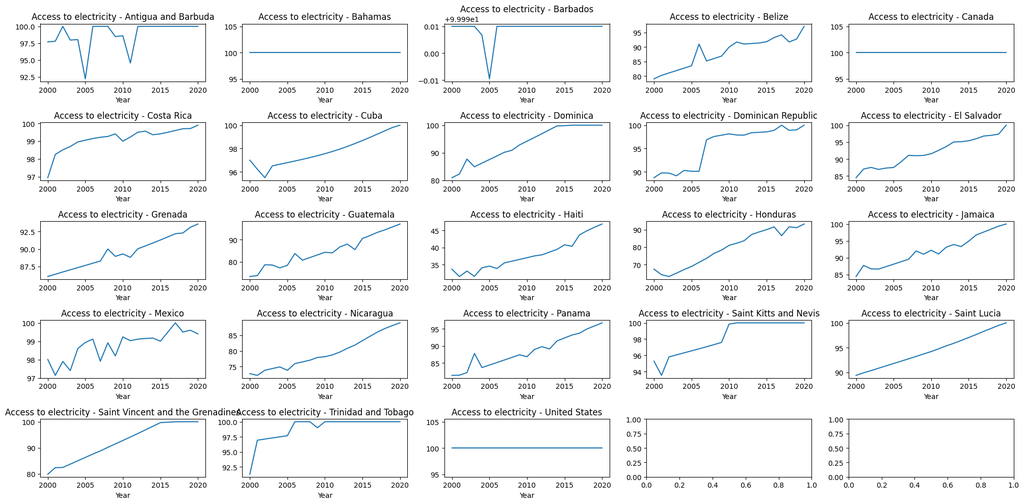

```python
access_to_electricity = North_america_df['Access to electricity (% of population)']
# Select unique countries from the index
countries = access_to_electricity.index.get_level_values('Entity').unique()

# Set up the subplot layout
num_rows = 5  # Number of rows of subplots
num_cols = 5  # Number of columns of subplots
num_plots = num_rows * num_cols
fig, axes = plt.subplots(num_rows, num_cols, figsize=(20, 10))

# Plotting for each country
for i, country in enumerate(countries[:num_plots]):
    row = i // num_cols
    col = i % num_cols
    country_data = access_to_electricity.loc[country]
    if num_rows == 1 or num_cols == 1:
        country_data.plot(kind='line', ax=axes[i], title=f'Access to electricity - {country}')
    else:
        country_data.plot(kind='line', ax=axes[row, col], title=f'Access to electricity - {country}')

# Adjust layout
plt.tight_layout()
plt.show()
```

This visualization efficiently uses multiple line charts to display time-series data for "Access to electricity (% of population)" across various countries. Line charts are an excellent choice for illustrating trends and patterns in variables across time. The addition of multiple graphs allows for a comparative analysis of power access levels and trends within a given region.Given the importance of electricity access as a development indicator, this visualization provides useful insights into the current state and evolution of electrification in the specified region.

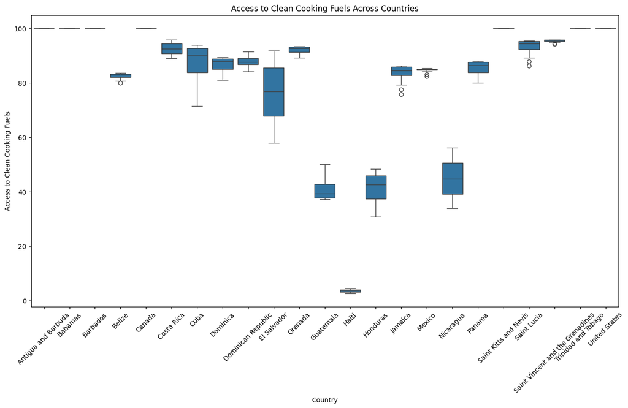

```python
plt.figure(figsize=(16, 8))
sns.boxplot(data=North_america_df, x='Entity', y='Access to clean fuels for cooking')
plt.title('Access to Clean Cooking Fuels Across Countries')
plt.xlabel('Country')
plt.ylabel('Access to Clean Cooking Fuels')
plt.xticks(rotation=45)
plt.show()
```

This box plot likely shows the distribution of access to clean cooking fuels across various countries. The horizontal axis (X-axis) represents countries and the vertical axis (Y-axis) represents a score indicating access to clean cooking fuels (higher values represent greater access). The box itself contains the middle half of the data (interquartile range). The line in the middle of the box represents the median (the 50th percentile, which divides the data in half). The whiskers extend from the box to the lowest and highest data points within 1.5 times the interquartile range. Any data points beyond the whiskers are considered outliers and are plotted individually.

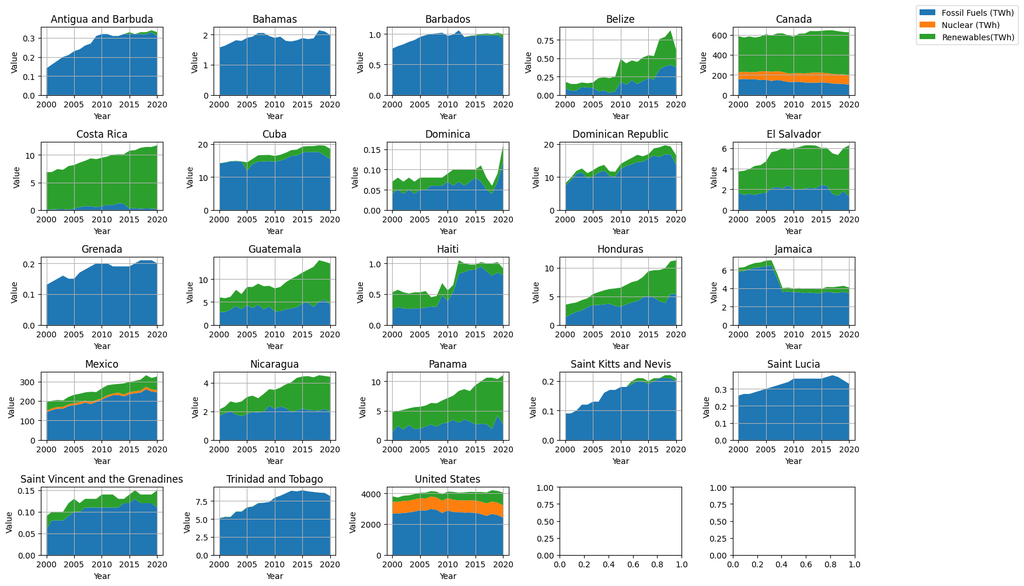

```python
# Select relevant columns for CO2 emissions and electricity generation from different sources
co2_emissions = North_america_df['Value_co2_emissions_kt_by_country']
electricity_fossil_fuels = North_america_df['Electricity from fossil fuels (TWh)']
electricity_nuclear = North_america_df['Electricity from nuclear (TWh)']
electricity_renewables = North_america_df['Electricity from renewables (TWh)']


# Set up the subplot layout
num_rows = 5  # Number of rows of subplots
num_cols = 5  # Number of columns of subplots
num_plots = num_rows * num_cols
fig, axes = plt.subplots(num_rows, num_cols, figsize=(15, 10))

# Plotting for each country
for i, country in enumerate(countries[:num_plots]):
    row = i // num_cols
    col = i % num_cols
    if country in North_america_df.index:
        country_data = North_america_df.loc[country]
        years = country_data.index.get_level_values('Year')
        # Stack the energy sources vertically
        stacked_data = np.vstack([electricity_fossil_fuels.loc[country], electricity_nuclear.loc[country], electricity_renewables.loc[country]])
        # Plot the stacked area chart
        axes[row, col].stackplot(years, stacked_data, labels=['Fossil Fuels (TWh)', 'Nuclear (TWh)', 'Renewables(TWh)'])
        axes[row, col].set_title(f'{country}')
        axes[row, col].set_xlabel('Year')
        axes[row, col].set_ylabel('Value')
        axes[row, col].grid(True)

# Create a single legend for all the subplots
handles, labels = axes[0, 0].get_legend_handles_labels()
fig.legend(handles, labels, loc='upper left', bbox_to_anchor=(1.05, 1), borderaxespad=0.)

# Adjust layout
plt.tight_layout()
plt.show()
```

This visualization offers a regional perspective on energy supply patterns. It reveals a common reliance on fossil fuels among the depicted countries. However, the adoption of nuclear and renewable alternatives varies considerably across these nations.

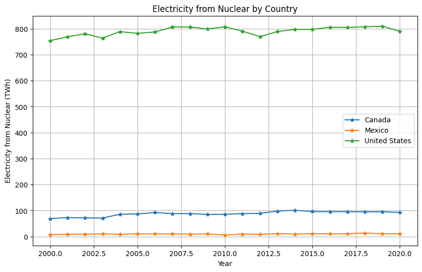

```python
# Selecting countries with non-zero values for electricity from nuclear
countries_with_nuclear = North_america_df[North_america_df['Electricity from nuclear (TWh)'] > 10].index.get_level_values('Entity').unique()

# Plotting for each country with non-zero values for electricity from nuclear
plt.figure(figsize=(10, 6))
for country in countries_with_nuclear:
    country_data = North_america_df.loc[country]
    years = country_data.index.get_level_values('Year')
    electricity_nuclear = country_data['Electricity from nuclear (TWh)']
    plt.plot(years, electricity_nuclear, label=country, marker="*")

# Adding labels and legend
plt.title('Electricity from Nuclear by Country')
plt.xlabel('Year')
plt.ylabel('Electricity from Nuclear (TWh)')
plt.legend()
plt.grid(True)

# Show plot
plt.show()
```

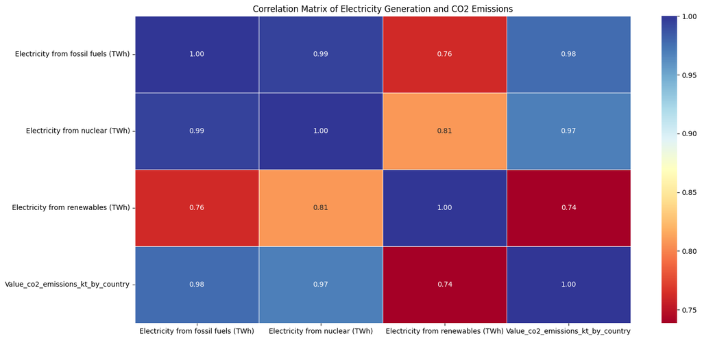

```python
# Select relevant columns for analysis
relevant_data = North_america_df[['Electricity from fossil fuels (TWh)', 'Electricity from nuclear (TWh)',
                      'Electricity from renewables (TWh)', 'Value_co2_emissions_kt_by_country']]

# Drop rows with any missing values
relevant_data.dropna()

# Calculate the correlation matrix
correlation_matrix = relevant_data.corr()

# Visualize the correlation matrix using a heatmap
plt.figure(figsize=(16, 8))
sns.heatmap(correlation_matrix, annot=True, cmap='RdYlBu', fmt=".2f", linewidths=.7)
plt.title('Correlation Matrix of Electricity Generation and CO2 Emissions')
plt.show()
```

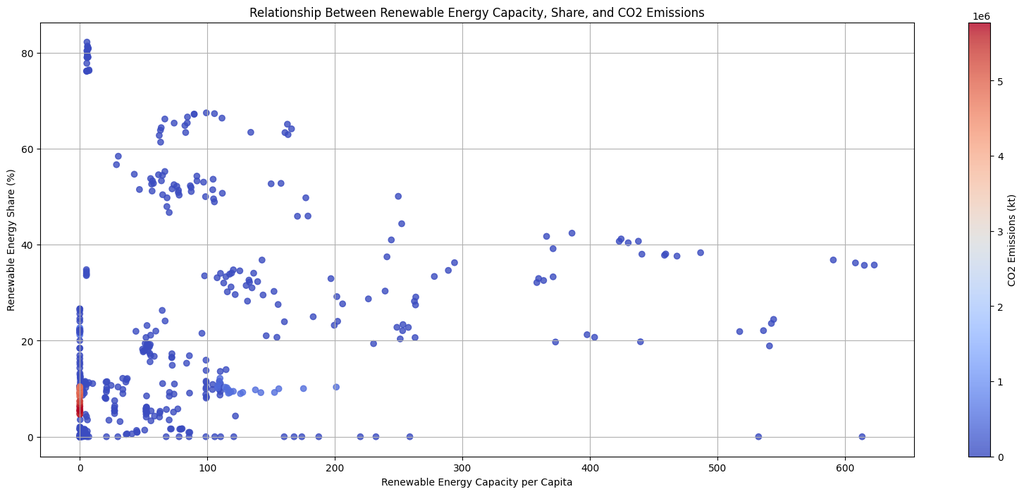

```python
# Define variables
renewable_capacity = North_america_df['Renewable-electricity-generating-capacity-per-capita']
renewable_share = North_america_df['Renewable energy share in the total final energy consumption (%)']
co2_emissions = North_america_df['Value_co2_emissions_kt_by_country']

# Create scatter plot
plt.figure(figsize=(20, 8))
plt.scatter(renewable_capacity, renewable_share, c=co2_emissions, cmap='coolwarm', alpha=0.8)
plt.colorbar(label='CO2 Emissions (kt)')
plt.xlabel('Renewable Energy Capacity per Capita')
plt.ylabel('Renewable Energy Share (%)')
plt.title('Relationship Between Renewable Energy Capacity, Share, and CO2 Emissions')
plt.grid(True)
plt.show()
```

## Further investigation and plausible model.

Model 1: Predicting Access to electricity

Q: Can we predict the future access to electricity in specific countries based on the historical data and other relevant features? To address this question we can use access to electricity as dependent variables and the gdp_per_capita, Financial flows to developing countries and other relevant features as the independent variable for further exploration.

- If the relation between dependent and independent variables are linear apply linear regression
- If the relationship is more complex and non-linear we can apply multi_linear or other Regression model like Random Forest Regression.

Model 2: Factors affecting Renewal energy adoption

Q: What are the most influential parameters in the adoption of renewable energy sources? (Renewable energy's percentage of total final energy consumption)

Use Renewable energy share in the total final energy consumption (%) as dependent variable and Electricity from fossil fuels (TWh), Primary energy consumption per capita (kWh/person), Value_co2_emissions_kt_by_country as independent variable and use a decision tree model to determine whether it is a good fit for understanding the decision-making process behind adopting renewable energy sources.